# Calibrating `nnil` on ZEAL by the Holland method: MolBreeding truth versus SNP50K skim

- Show All Code
- Hide All Code
- View Source

Author

Fausto Rodríguez-Zapata

Published

July 23, 2026

**NoteScope: a faithful ZEAL recreation of Holland’s nNIL calibration, on real data**

This reproduces Zhong et al.’s (2025) nNIL calibration on the ZEAL population. MolBreeding target-capture sequencing (~110x) plays the role of Holland’s chip (the **truth**); the SNP50K skim (~0.4x) plays the role of his GBS (the **test**); and `nnil` is calibrated against Holland’s objective, the **per-cell ancestry mismatch** between the two platforms. The truth is `nnil` run on the MolBreeding hard calls (Holland runs the HMM on the chip too); the test is the skim hard-called then run through the same `nnil` over Holland’s emission grid. Compute lives in the tracked scripts (`scripts/stage_molbreeding_from_zealtiger.sh`, `scripts/molbreeding/extract_molbreeding_hardcalls.R`, `scripts/molbreeding/build_calibration_pairing.R`, `scripts/molbreeding_skim_calibration.R`); this notebook reads their outputs. Markers are on maize v5; the genetic map is the native TeoNAM v5 map.

Holland’s calibration minimises the disagreement between two genotyping platforms on the lines assayed on both: high-coverage chip calls define the truth, the cheap GBS is run through the HMM, and the HMM parameters are chosen to minimise the per-cell ancestry-call mismatch. ZEAL has the same structure with different platforms: **MolBreeding** target sequencing (~110x, the informative-marker truth) and the **SNP50K skim** (~0.4x, the population-scale genotyping). This notebook asks the same question Holland asked, on ZEAL: what `nnil` parameters minimise the skim-versus-MolBreeding mismatch, and, because the skim genotype call is a choice we have to make, whether a maximum-likelihood or a breeding-design genotype prior serves the calibration better.

```r
suppressMessages({
  library(data.table)
  library(ggplot2)
  library(patchwork)
  library(here)
  library(knitr)
})
theme_z <- theme_classic(base_size = 10) +
  theme(
    text = element_text(family = "sans"),
    plot.tag = element_text(face = "bold"),
    legend.position = "top", legend.title = element_blank(),
    axis.text.x = element_text(angle = 45, hjust = 1)
  )
col_ml <- "#0072B2" # ML / flat genotype-call prior
col_br <- "#D55E00" # BC2S3 breeding-design genotype-call prior

# the parameter sweep (skim test vs MolBreeding truth), 945 configs x 2 skim priors.
# "flat" = call_gt(prior = "flat") = argmax-GL = the maximum-likelihood genotype call;
# relabel to ML for display (the two are identical).
sweep <- fread(here("data/zeal/molbreeding_skim_calibration.csv"))
# normalize the skim genotype-call prior labels (robust to older flat/design runs):
# ML = the maximum-likelihood (flat) call; breeding = the BC2S3 breeding-design prior.
sweep[prior %in% c("flat", "ml"), prior := "ML"]
sweep[prior %in% c("design", "breeding"), prior := "breeding"]
sweep[, prior := factor(prior, levels = c("ML", "breeding"))]

pair <- fread(here("data/zeal/correspondence/calibration_pairing.csv"))
hc <- fread(here("data/zeal/molbreeding/molbreeding_hardcalls_wsfilt.tsv"))
```

## 1. Holland’s pipeline, mapped to ZEAL

```r
map_tab <- data.table(
  role = c("truth (high coverage)", "test (low coverage)", "objective", "sites", "map"),
  Holland_nNIL = c("chip nnil calls", "GBS nnil calls", "per-cell ancestry mismatch (GBS-nnil vs chip-nnil)",
    "chip-GBS shared: 11,310", "native TeoNAM v5 cM"),
  ZEAL = c("targseq nnil calls (~110x)", "skim nnil calls (~0.4x)", "per-cell ancestry mismatch (skim-nnil vs targseq-nnil)",
    "teosinte-informative: 9,157", "native TeoNAM v5 cM")
)
kable(map_tab, col.names = c("role", "Holland nNIL", "ZEAL"),
  caption = "The nNIL calibration structure, and the ZEAL platforms that play each role.")
```

The nNIL calibration structure, and the ZEAL platforms that play each role.

| role | Holland nNIL | ZEAL |
| --- | --- | --- |
| truth (high coverage) | chip nnil calls | targseq nnil calls (~110x) |
| test (low coverage) | GBS nnil calls | skim nnil calls (~0.4x) |
| objective | per-cell ancestry mismatch (GBS-nnil vs chip-nnil) | per-cell ancestry mismatch (skim-nnil vs targseq-nnil) |
| sites | chip-GBS shared: 11,310 | teosinte-informative: 9,157 |
| map | native TeoNAM v5 cM | native TeoNAM v5 cM |

The calibration runs on the lines assayed on **both** platforms. Sample identity is matched by canonical pedigree (skim and MolBreeding share the `PN#_SID#` id space; `scripts/zeal_build_samplesheet.R`), giving 14 NIL pairs plus two B73-bulk controls. One pair carries a documented MolBreeding-side well swap: the truth labelled `PN4_SID330` is genotypically `PN4_SID322` (donor Jaccard 0.84 versus skim-322, 0.10 versus its own label), so it is paired to skim `PN4_SID322`; the canonical correspondence table is left unchanged and the override is applied only here.

```r
cal <- pair[in_calibration == TRUE]
kable(cal[, .(truth_sample, test_sample, true_pedigree,
  note = fifelse(note == "", "", "Jaccard-corrected pair"))],
  caption = sprintf("The %d calibration NIL pairs (truth MolBreeding sample <-> test skim sample). The B73-bulk checks are MolBreeding-only controls and are not scored.", nrow(cal)))
```

The 14 calibration NIL pairs (truth MolBreeding sample <-> test skim sample). The B73-bulk checks are MolBreeding-only controls and are not scored.

| truth_sample | test_sample | true_pedigree | note |
| --- | --- | --- | --- |
| PN12_SID1101 | PN12_SID1101 | Zv.0080_P2_P3_P1.1.1.1 |  |
| PN4_SID290 | PN4_SID290 | Zx.0340_P2_P1_P1.1.1.1 |  |
| PN4_SID291 | PN4_SID291 | Zx.0340_P2_P1_P1.2.1.1 |  |
| PN4_SID293 | PN4_SID293 | Zx.0340_P2_P1_P2.2.1.1 |  |
| PN4_SID309 | PN4_SID309 | Zx.0150_P2_P1_P1.1.1.1 |  |
| PN4_SID320 | PN4_SID320 | Zx.0030_P2_P1_P2.1.1.1 |  |
| PN4_SID330 | PN4_SID322 | Zx.0030_P2_P2_P1.2.1.1 | Jaccard-corrected pair |
| PN4_SID359 | PN4_SID359 | Zx.0560_P2_P3_P2.1.1.1 |  |
| PN6_SID492 | PN6_SID492 | Zx.0540_P3_P4_P4.3.1.1 |  |
| PN6_SID507 | PN6_SID507 | Zx.0440_P1_P1_P1.3.1.1 |  |
| PN6_SID509 | PN6_SID509 | Zx.0440_P1_P3_P1.2.1.1 |  |
| PN6_SID524 | PN6_SID524 | Zd.0030_P2_P1_P1.2.1.1 |  |
| PN6_SID568 | PN6_SID568 | Zd.0030_P2_P4_P4.3.1.1 |  |
| PN6_SID575 | PN6_SID575 | Zd.0030_P2_P5_P1.2.1.1 |  |

The MolBreeding truth carries real heterozygosity, which matters for what follows: the skim is being asked to recover het introgression that genuinely exists. Compared against the neutral **BC2S3 single-locus expectation** (2 backcrosses to B73, then 3 selfs), the truth already shows a **donor deficiency**: a heterozygote excess, a homozygous-donor deficit, and a lower overall donor-allele frequency than neutral.

```r
obs <- hc[name %in% cal$truth_sample & !is.na(g) & g != 3L]
fr <- obs[, .N, by = g][order(g)][, f := N / sum(N)]
# neutral single-locus BC2S3 expectation, from the backcross/selfing transition matrices
# (2 backcrosses to AA=B73, then 3 selfs); reproduces breeding_prior("BC2S3") exactly.
Bm <- matrix(c(1, 0, 0, 0.5, 0.5, 0, 0, 1, 0), 3, byrow = TRUE) # backcross to AA
Sm <- matrix(c(1, 0, 0, 0.25, 0.5, 0.25, 0, 0, 1), 3, byrow = TRUE) # selfing
p0 <- c(0, 1, 0) # F1
for (i in 1:2) p0 <- as.vector(p0 %*% Bm)
for (i in 1:3) p0 <- as.vector(p0 %*% Sm)
maf_obs <- fr$f[fr$g == 1] / 2 + fr$f[fr$g == 2]
maf_exp <- p0[2] / 2 + p0[3]
comp <- data.table(
  state = c("REF (recurrent)", "HET (introgression)", "ALT (homozygous donor)", "MAF (donor allele freq)"),
  `molb (observed)` = round(c(fr$f, maf_obs), 4),
  `expected (BC2S3 neutral)` = round(c(p0, maf_exp), 4)
)
kable(comp, caption = "MolBreeding truth composition over the 14 samples versus the neutral BC2S3 single-locus expectation. The donor deficiency is clear: het excess (0.090 vs 0.031), homozygous-donor deficit (0.026 vs 0.109), and overall donor-allele frequency well below neutral (0.071 vs 0.125).")
```

MolBreeding truth composition over the 14 samples versus the neutral BC2S3 single-locus expectation. The donor deficiency is clear: het excess (0.090 vs 0.031), homozygous-donor deficit (0.026 vs 0.109), and overall donor-allele frequency well below neutral (0.071 vs 0.125).

| state | molb (observed) | expected (BC2S3 neutral) |
| --- | --- | --- |
| REF (recurrent) | 0.8842 | 0.8594 |
| HET (introgression) | 0.0902 | 0.0312 |
| ALT (homozygous donor) | 0.0256 | 0.1094 |
| MAF (donor allele freq) | 0.0707 | 0.1250 |

## 2. The skim genotype-call choice: maximum-likelihood versus the breeding-design prior

`nnil` ingests hard genotype calls, so the skim counts must first be called into genotypes, and the prior for that call is a modelling choice. We compare two:

- **ML** (`call_gt(prior = "flat")`): the uniform-prior maximum-likelihood call (`argmax` of the genotype likelihood), the standard data-only caller. Het-blind at depth 1 (a lone ALT read is called homozygous), so it can only call het where at least two reads show both alleles.
- **breeding** (`call_gt(prior = breeding_prior("BC2S3"))`): the BC2S3 breeding-design prior, which encodes the expected donor content and actively resists het.

Holland’s grid (945 configurations) is swept identically on both, and each configuration’s skim calls are scored against the MolBreeding truth. Reported at each prior’s mismatch-optimal configuration:

```r
best <- sweep[, .SD[which.min(mismatch)], by = prior]
comp <- best[, .(
  prior,
  `mismatch (primary)` = round(mismatch, 4),
  `nir*` = nir, `p*` = p, `r*` = r,
  het_recall = round(het_recall, 3),
  alt_recall = round(alt_recall, 3),
  donor_recall = round(donor_marker_recall, 3),
  DSC = round(donor_frag_dice, 3),
  FDR = round(donor_frag_FDR, 3),
  KS = round(ks_fragsize, 3)
)][order(prior)]
kable(comp, caption = "Skim caller calibrated under each genotype-call prior, at the per-cell mismatch optimum. DSC = donor-fragment Dice-Sorensen coefficient; FDR = donor-fragment false-discovery rate; KS = fragment-size Kolmogorov-Smirnov distance versus truth. Starred columns are the swept parameters at the optimum.")
```

Skim caller calibrated under each genotype-call prior, at the per-cell mismatch optimum. DSC = donor-fragment Dice-Sorensen coefficient; FDR = donor-fragment false-discovery rate; KS = fragment-size Kolmogorov-Smirnov distance versus truth. Starred columns are the swept parameters at the optimum.

| prior | mismatch (primary) | nir* | p* | r* | het_recall | alt_recall | donor_recall | DSC | FDR | KS |
| --- | --- | --- | --- | --- | --- | --- | --- | --- | --- | --- |
| ML | 0.1336 | 0.700 | 0.10 | 0.001 | 0.085 | 0.935 | 0.758 | 0.347 | 0.695 | 0.369 |
| breeding | 0.1377 | 0.001 | 0.25 | 0.010 | 0.002 | 0.363 | 0.120 | NA | 1.000 | 0.935 |

The ML caller is therefore the calibration basis; the breeding prior is kept only as the het-suppressing foil.

## 3. The objective, and the het floor it exposes

Per-cell mismatch is minimised along `nir`; the other swept parameters move it little (quantified by the variance-component analysis below). The primary objective as a function of `nir`:

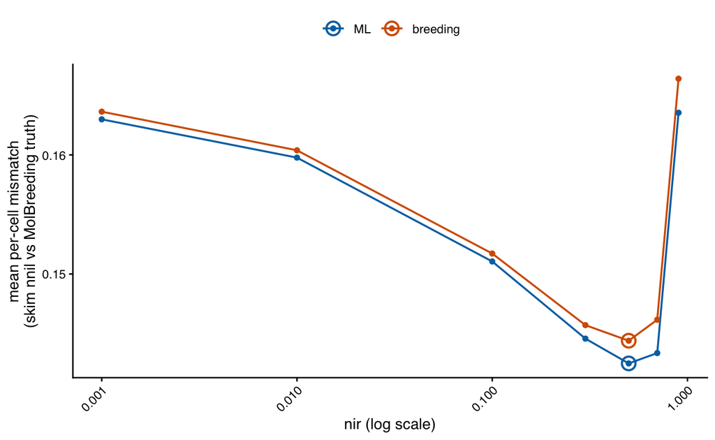

```r
mm <- sweep[, .(mismatch = mean(mismatch)), by = .(prior, nir)]
mn <- mm[, .SD[which.min(mismatch)], by = prior]
ggplot(mm, aes(nir, mismatch, colour = prior)) +
  geom_line(linewidth = 0.6) + geom_point(size = 1.3) +
  geom_point(data = mn, shape = 21, size = 3.5, stroke = 1, fill = NA) +
  scale_x_log10() +
  scale_colour_manual(values = c(ML = col_ml, breeding = col_br)) +
  labs(x = "nir (log scale)", y = "mean per-cell mismatch\n(skim nnil vs MolBreeding truth)") +
  theme_z
```

### Variance components of the objective (ML calibration)

A main-effects ANOVA of the ML calibration’s per-cell mismatch against the five swept parameters shows `nir` dominates (about 61% of the parameter-attributable variance); the recombination prior `r` is a distant second (about 7%); and `germ`, `gert`, `p` each contribute under 3%.

```r
d <- sweep[prior == "ML"]
aov <- anova(lm(mismatch ~ factor(nir) + factor(germ) + factor(gert) + factor(p) + factor(r), d))
ss <- aov[["Sum Sq"]]
nm <- sub("factor\\((.*)\\)", "\\1", rownames(aov))
nm[nm == "Residuals"] <- "residual"
vtab <- data.table(term = factor(nm, c("nir", "germ", "gert", "p", "r", "residual")),
  `variance share (%)` = round(100 * ss / sum(ss), 1))
setorder(vtab, term)
kable(vtab, caption = "Main-effects ANOVA variance share of the ML calibration's per-cell mismatch attributed to each swept parameter. nir dominates; the residual is the per-(marker,line) structure the main-effects model does not capture.")
```

Main-effects ANOVA variance share of the ML calibration’s per-cell mismatch attributed to each swept parameter. nir dominates; the residual is the per-(marker,line) structure the main-effects model does not capture.

| term | variance share (%) |
| --- | --- |
| nir | 61.0 |
| germ | 2.9 |
| gert | 0.2 |
| p | 0.1 |
| r | 6.9 |
| residual | 28.9 |

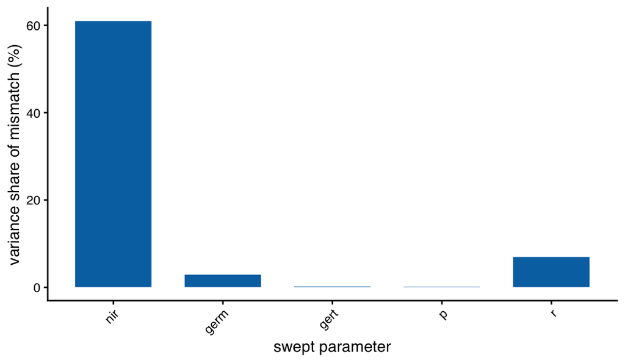

Figure 2: Variance share of the ML calibration’s per-cell mismatch explained by each swept parameter (main-effects ANOVA, residual omitted). nir carries the calibration; r is a weak second; germ/gert/p are near-flat.

```r
vp <- vtab[term != "residual"]
ggplot(vp, aes(term, `variance share (%)`)) +
  geom_col(fill = col_ml, width = 0.7) +
  labs(x = "swept parameter", y = "variance share of mismatch (%)") +
  theme_z
```

So `nir` carries the calibration (the ML caller places its optimum at `nir` = 0.7, Section 2), with the recombination prior `r` a weak secondary axis examined next. The large residual reflects between-marker and between-line variation the parameters do not touch, consistent with the mismatch floor being a data property (coverage) rather than a tuning target.

### The recombination prior `r`: mismatch trades against over-fragmentation

In Holland’s nNIL `r` is a benign hyperparameter (0.03% of the objective, a flat plateau), so the map value is safe and no calibration of `r` is needed. On the ZEAL skim `r` behaves differently: it carries about 7% of the mismatch variance, and per-cell mismatch **falls weakly as `r` rises** (0.156 at `r`=1e-6 to 0.148 at 1e-2, a 0.0085 range). But that apparent improvement is **over-fragmentation, not better calling**: as `r` rises the donor-fragment FDR climbs (0.65 to 0.89) and the breakpoint ratio balloons (0.9 to 6.3x the truth). Minimising mismatch alone would therefore push `r` spuriously high; the fragment diagnostics show it is manufacturing false donor blocks. The map-derived `r` (~3.2e-4, mid-grid, breakpoint ratio ~2) is the principled anchor, set by the genetic map rather than by the mismatch curve.

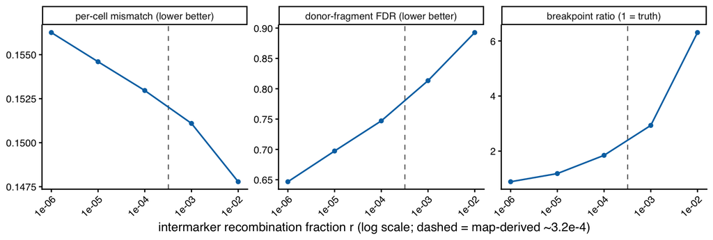

Figure 3: Recombination-prior sweep, ML skim caller, marginal over the emission grid. Per-cell mismatch (left) falls weakly as r rises, but the donor-fragment FDR (middle) and the breakpoint ratio (right, 1 = truth) both climb steeply: the lower mismatch at high r is over-fragmentation, not better calling. Dashed line, the SNP50K map-derived r ~3.2e-4, the principled anchor. Unlike Holland’s nNIL, r is not a benign hyperparameter on ZEAL skim, but the map value still lands in the sensible region.

```r
map_r_skim <- 3.2e-4
rs <- melt(sweep[prior == "ML", .(mismatch = mean(mismatch),
  donor_frag_FDR = mean(donor_frag_FDR), breakpoint_ratio = mean(breakpoint_ratio)), by = r],
  id.vars = "r", variable.name = "metric", value.name = "value")
rs[, metric := factor(metric, c("mismatch", "donor_frag_FDR", "breakpoint_ratio"),
  c("per-cell mismatch (lower better)", "donor-fragment FDR (lower better)", "breakpoint ratio (1 = truth)"))]
ggplot(rs, aes(r, value)) +
  geom_vline(xintercept = map_r_skim, linetype = "dashed", colour = "grey40", linewidth = 0.4) +
  geom_line(colour = col_ml, linewidth = 0.6) + geom_point(colour = col_ml, size = 1.3) +
  facet_wrap(~metric, scales = "free_y", nrow = 1) +
  scale_x_log10() +
  labs(x = "intermarker recombination fraction r (log scale; dashed = map-derived ~3.2e-4)", y = NULL) +
  theme_z
```

The mismatch floor is a **het floor**. The skim recovers homozygous donor well (`alt_recall` about 0.90 to 0.94) but recovers almost no het (`het_recall` about 0.09 even under ML), while about 9% of the truth genome is het (Section 1). At 0.4x, with 71% of markers uncovered and most covered markers at depth 1, the skim cannot see the two alleles a het call needs; the ML prior helps at the sites with two reads but cannot manufacture coverage. This is the coverage-limited failure mode the calibration is meant to characterise, not a tuning artefact.

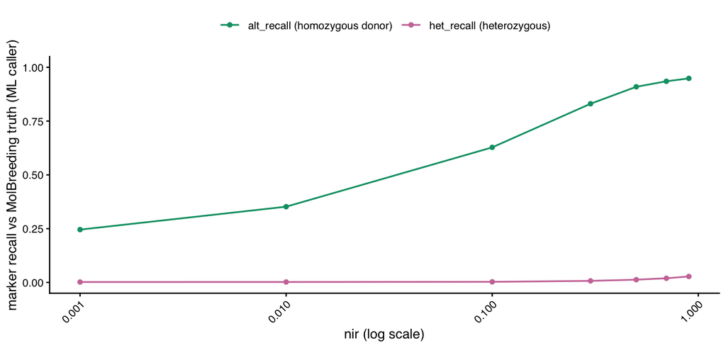

Figure 4: State-resolved donor recovery versus nir, ML skim caller. Homozygous-donor markers (alt_recall) are recovered across nir; heterozygous markers (het_recall) are barely recovered at all, capped by 0.4x coverage. The skim reads ZEAL introgression as homozygous-donor blocks and misses the het.

```r
rr <- melt(sweep[prior == "ML", .(het_recall = mean(het_recall), alt_recall = mean(alt_recall)),
  by = nir], id.vars = "nir", variable.name = "state", value.name = "recall")
rr[, state := factor(state, c("alt_recall", "het_recall"),
  c("alt_recall (homozygous donor)", "het_recall (heterozygous)"))]
ggplot(rr, aes(nir, recall, colour = state)) +
  geom_line(linewidth = 0.6) + geom_point(size = 1.3) +
  scale_x_log10() + ylim(0, 1) +
  scale_colour_manual(values = c("alt_recall (homozygous donor)" = "#009E73",
    "het_recall (heterozygous)" = "#CC79A7")) +
  labs(x = "nir (log scale)", y = "marker recall vs MolBreeding truth (ML caller)") +
  theme_z
```

## 4. Fragment-size distributions across the sweeps

The over-fragmentation the diagnostics flagged is visible directly in the donor-fragment-size distribution, and it shows both knobs converging on the truth at the calibrated operating point. The truth (black dashed) has ~154 donor blocks (median ~15 Mb).

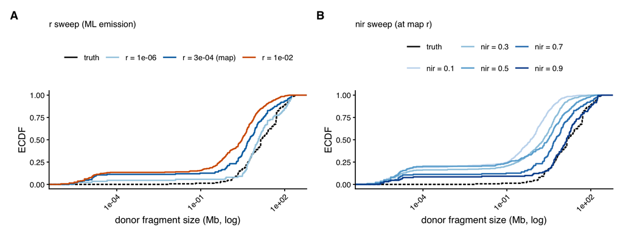

```r
fs <- fread(here("data/zeal/molbreeding_skim_fragsize.csv"))
fa <- fs[panel %in% c("both", "r")]
fa[, series := factor(series, levels = c("truth", "r = 1e-06", "r = 3e-04 (map)", "r = 1e-02"))]
pA <- ggplot(fa, aes(size_mb, colour = series, linetype = series == "truth")) +
  stat_ecdf(linewidth = 0.7) +
  scale_x_log10() +
  scale_colour_manual(values = c("truth" = "black", "r = 1e-06" = "#a6cee3",
    "r = 3e-04 (map)" = col_ml, "r = 1e-02" = col_br)) +
  scale_linetype_manual(values = c(`FALSE` = "solid", `TRUE` = "21"), guide = "none") +
  labs(x = "donor fragment size (Mb, log)", y = "ECDF", tag = "A", title = "r sweep (ML emission)") +
  theme_z + theme(legend.title = element_blank(), plot.title = element_text(size = 9))
fb <- fs[panel %in% c("both", "nir")]
fb[, series := factor(series, levels = c("truth", sprintf("nir = %.1f", c(0.1, 0.3, 0.5, 0.7, 0.9))))]
pB <- ggplot(fb, aes(size_mb, colour = series, linetype = series == "truth")) +
  stat_ecdf(linewidth = 0.7) +
  scale_x_log10() +
  scale_colour_manual(values = c("truth" = "black", "nir = 0.1" = "#c6dbef", "nir = 0.3" = "#9ecae1",
    "nir = 0.5" = "#6baed6", "nir = 0.7" = "#3182bd", "nir = 0.9" = "#08519c")) +
  scale_linetype_manual(values = c(`FALSE` = "solid", `TRUE` = "21"), guide = "none") +
  labs(x = "donor fragment size (Mb, log)", y = "ECDF", tag = "B", title = "nir sweep (at map r)") +
  theme_z + theme(legend.title = element_blank(), plot.title = element_text(size = 9))
pA + pB
```

On these size ECDFs a leftward shift means smaller blocks (over-fragmentation). The truth (black dashed) has the largest blocks (median ~15 Mb). Sweeping `r` (A) shifts the distribution left as `r` rises: `r` = 1e-6 is nearest the truth, the map `r` is intermediate, and `r` = 1e-2 is badly over-fragmented. Sweeping `nir` (B) shifts it right toward the truth as `nir` rises: from shattered at `nir` = 0.1 (median 0.7 Mb) up to `nir` = 0.9, which tracks the truth size distribution most closely. Size and count do not pick the same config: the block *count* matches the truth (154) at the operating point (map `r`, `nir` = 0.7; ~151 blocks), while the size *distribution* is closest at `nir` = 0.9 (and the lowest `r`) – so the operating point calls the right *number* of donor blocks but they run somewhat smaller than the truth’s. Either view is the fragment-level counterpart of the `r`-over-fragmentation and `nir`-under-calling the metrics quantified.

### Holland’s published `nir` = 0.9 is the fragment-optimum, not the mismatch-optimum

The same tension shows up directly if we evaluate Holland’s published emission (`nir` = 0.9, `germ` = 1e-3, `gert` = 1e-4, `p` = 0.9) at `r` = 1.67e-3, ML skim against the MolBreeding truth, alongside the per-cell mismatch optimum (`nir` = 0.7):

```r
h <- fread(here("data/zeal/molbreeding_skim_holland_config.csv"))
opt <- sweep[prior == "ML"][which.min(mismatch)]
htab <- data.table(
  metric = c("mismatch (primary)", "donor_marker_recall", "het_recall", "alt_recall",
    "donor_frag_DSC", "donor_frag_FDR", "ks_fragsize", "breakpoint_ratio"),
  value = c(round(h$mismatch, 4), round(h$donor_marker_recall, 3), round(h$het_recall, 3),
    round(h$alt_recall, 3), round(h$donor_frag_dice, 3), round(h$donor_frag_FDR, 3),
    round(h$ks_fragsize, 3), round(h$breakpoint_ratio, 2)),
  `vs mismatch-optimum (nir = 0.7)` = c(
    sprintf("worse (%.4f)", opt$mismatch),
    sprintf("~ (%.3f) better", opt$donor_marker_recall),
    "worse, high nir suppresses het",
    sprintf("~ (%.3f)", opt$alt_recall),
    sprintf("better (%.3f)", opt$donor_frag_dice),
    sprintf("better (%.3f)", opt$donor_frag_FDR),
    "better",
    "near-perfect (~ truth count)"
  )
)
kable(htab, caption = "Holland's published nir = 0.9 emission (germ 1e-3, gert 1e-4, p 0.9) at r = 1.67e-3, ML skim vs MolBreeding truth, against the per-cell mismatch optimum (nir = 0.7).")
```

Holland’s published nir = 0.9 emission (germ 1e-3, gert 1e-4, p 0.9) at r = 1.67e-3, ML skim vs MolBreeding truth, against the per-cell mismatch optimum (nir = 0.7).

| metric | value | vs mismatch-optimum (nir = 0.7) |
| --- | --- | --- |
| mismatch (primary) | 0.1697 | worse (0.1336) |
| donor_marker_recall | 0.8900 | ~ (0.758) better |
| het_recall | 0.0060 | worse, high nir suppresses het |
| alt_recall | 0.9600 | ~ (0.935) |
| donor_frag_DSC | 0.4300 | better (0.347) |
| donor_frag_FDR | 0.5610 | better (0.695) |
| ks_fragsize | 0.1600 | better |
| breakpoint_ratio | 1.0100 | near-perfect (~ truth count) |

So this config (Holland’s published `nir` = 0.9) is the **fragment-optimal** operating point, best DSC, lowest FDR, best fragment-size KS, and breakpoint ratio ~1 (it recovers the truth’s block count almost exactly), but it is **mismatch-worse** (0.170 vs 0.134) and **het-blind** (`het_recall` ~0.006): high `nir` merges everything into homozygous-donor blocks.

## 5. Calibrated parameters

The calibrated ZEAL skim caller, next to the truth caller. The swept parameters (`nir, germ, gert, p, r`) are the grid-search result; `mr` (the missing-genotype rate) is a fixed empirical input estimated once from each platform’s own missingness, not a searched value (as in `File_S16.py`), and the `molb gt` column is the fixed truth-caller configuration, not a search result.

```r
b <- sweep[, .SD[which.min(mismatch)], by = prior]
ptab <- data.table(
  parameter = c("nir", "germ", "gert", "p", "r", "mr (fixed input)"),
  `molb gt` = c("0.7", "1e-3", "1e-4", "0.90", "1.67e-3", "~0"),
  `BC2S3 prior gt` = c(b[prior == "breeding", sprintf("%g", c(nir, germ, gert, p, r))], "0.709"),
  `flat prior gt` = c(b[prior == "ML", sprintf("%g", c(nir, germ, gert, p, r))], "0.709")
)
kable(ptab, caption = "nnil parameters by the genotype calls fed in: molb gt = the MolBreeding truth (fixed config, on the 9,157 informative sites); BC2S3 prior gt and flat prior gt = the skim calls hard-called under the BC2S3-design and flat (maximum-likelihood) genotype priors. Swept parameters (nir, germ, gert, p, r) are the grid-search result; mr is a fixed empirical input, not searched. r is panel-scaled (molb gt 1.67e-3 over 9,157 sites; skim over 51,991 SNP50K sites, around the map-derived 3.2e-4).")
```

nnil parameters by the genotype calls fed in: molb gt = the MolBreeding truth (fixed config, on the 9,157 informative sites); BC2S3 prior gt and flat prior gt = the skim calls hard-called under the BC2S3-design and flat (maximum-likelihood) genotype priors. Swept parameters (nir, germ, gert, p, r) are the grid-search result; mr is a fixed empirical input, not searched. r is panel-scaled (molb gt 1.67e-3 over 9,157 sites; skim over 51,991 SNP50K sites, around the map-derived 3.2e-4).

| parameter | molb gt | BC2S3 prior gt | flat prior gt |
| --- | --- | --- | --- |
| nir | 0.7 | 0.001 | 0.7 |
| germ | 1e-3 | 0.0001 | 0.0001 |
| gert | 1e-4 | 0.01 | 0.01 |
| p | 0.90 | 0.25 | 0.1 |
| r | 1.67e-3 | 0.01 | 0.001 |
| mr (fixed input) | ~0 | 0.709 | 0.709 |

Reading the `flat prior gt` column against `molb gt`: `nir` = 0.7 matches the truth and the authentic donor rate; `gert` = 1e-2 (versus 1e-4 for the truth) is the calibration learning that skim heterozygote calls are unreliable, while `germ` = 1e-4 keeps the reliable single-read homozygous calls; the low `p` = 0.10 routes residual homozygous errors to the opposite homozygote rather than manufacturing het (`p` is weakly identified, about 0% of the objective variance, but where it is identifiable under ML it prefers low).

**ImportantCalibrated ZEAL skim caller, and what the calibration establishes**

Call the skim genotypes by **maximum likelihood** (`call_gt(prior = "flat")`), then `nnil` with `nir` = 0.7 (matching the MolBreeding truth and the authentic donor non-informative rate), `germ` = 1e-4, `gert` = 1e-2, `p` low, and `r` at the SNP50K map-derived rate; `mr` is set to the realized missing rate. Under this calibration the ZEAL skim recovers **homozygous-donor introgression** faithfully (`alt_recall` about 0.9) but **not heterozygous** introgression (`het_recall` about 0.09 against a 9% het truth): at 0.4x the skim reads ZEAL ancestry as homozygous-donor blocks. The breeding prior is worse on every metric because its het-suppression compounds the coverage limit. The mismatch floor is therefore a coverage-driven het floor, quantified here against the MolBreeding truth.